# Coursera PML - Week 4 Assignment

Pat Molloy

23 April 2016

## Practical Machine Learning: Week 4 Assignment: Quantified Self Movement Data

Using devices such as Jawbone Up, Nike FuelBand, and Fitbit it is now possible to collect a large amount of data about personal activity relatively inexpensively. These type of devices are part of the quantified self movement – a group of enthusiasts who take measurements about themselves regularly to improve their health, to find patterns in their behavior, or because they are tech geeks. One thing that people regularly do is quantify how much of a particular activity they do, but they rarely quantify how well they do it. In this project, your goal will be to use data from accelerometers on the belt, forearm, arm, and dumbell of 6 participants. They were asked to perform barbell lifts correctly and incorrectly in 5 different ways. More information is available from the website here: http://groupware.les.inf.puc-rio.br/har (see the section on the Weight Lifting Exercise Dataset).

In this project, thegoal will be to use data from accelerometers on the belt, forearm, arm, and dumbell of 6 participants. They were asked to perform barbell lifts correctly and incorrectly in 5 different ways (A,B,C,D,E - the classe variable)

> The goal is to build a model to predict the manner in which they did the exercise.

# Data

The training data for this project are available here:

https://d396qusza40orc.cloudfront.net/predmachlearn/pml-training.csv

The test data are available here:

https://d396qusza40orc.cloudfront.net/predmachlearn/pml-testing.csv

# Load the data

```r
trainUrl <-"https://d396qusza40orc.cloudfront.net/predmachlearn/pml-training.csv"
testUrl <- "https://d396qusza40orc.cloudfront.net/predmachlearn/pml-testing.csv"
trainFile <- "./data/pml-training.csv"
testFile  <- "./data/pml-testing.csv"
if (!file.exists("./data")) {
  dir.create("./data")
}
if (!file.exists(trainFile)) {
  download.file(trainUrl, destfile=trainFile, method="internal")
}
if (!file.exists(testFile)) {
  download.file(testUrl, destfile=testFile, method="internal")
}
```

# Read the data

We can read the data (training and test) into two data frames

```r
trainRaw <- read.csv("./data/pml-training.csv",na.strings = c("NA", ""),strip.white=T)
testRaw <- read.csv("./data/pml-testing.csv",na.strings = c("NA", ""),strip.white=T)
dim(trainRaw)
```

```
## [1] 19622   160
```

```r
dim(testRaw)
```

```
## [1]  20 160
```

We end up with 160 columns of data (variables). With 19,622 observations in the taining set and 20 in the test set.

# Data Cleaning

Keep only variables where there are no NA’s ; additionally remove irrelevant varibles (e.g. demographic stuf)

```r
isNA <- apply(trainRaw, 2, function(x) { sum(is.na(x)) })
validData <- subset(trainRaw[, which(isNA == 0)],
                    select=-c(X, user_name, new_window, num_window, raw_timestamp_part_1, raw_timestamp_part_2, cvtd_timestamp))
dim(validData)
```

```
## [1] 19622    53
```

So, we are now down to 53 columns (variables). Let’s partition (70% / 30%) into training and test sets

```r
set.seed(12345) # ensure this can be repoduced
inTrain <- createDataPartition(validData$classe, p=0.70, list=F)
training <- validData[inTrain,]
testing <- validData[-inTrain,]
```

# Data Modeling using Random Forest

Now we’ll train a Random Forest model on the training set. (Using this particular combination of trControl parameters is important, as by default bootstrapping is used, which can be time consuming). Use 4-fold cross validation.

```r
ctrl <- trainControl(allowParallel=T, method="cv", number=4)
model <- train(classe ~ ., data=training, model="rf", trControl=ctrl)
pred <- predict(model, newdata=testing)

sum(pred == testing$classe) / length(pred)
```

```
## [1] 0.9918437
```

```r
confusionMatrix(testing$classe, pred)
```

```
## Confusion Matrix and Statistics
##
##           Reference
## Prediction    A    B    C    D    E
##          A 1671    3    0    0    0
##          B   10 1126    3    0    0
##          C    0    6 1015    5    0
##          D    1    0   13  950    0
##          E    0    0    1    6 1075
##
## Overall Statistics
##
##                Accuracy : 0.9918
##                  95% CI : (0.9892, 0.994)
##     No Information Rate : 0.2858
##     P-Value [Acc > NIR] : < 2.2e-16
##
##                   Kappa : 0.9897
##  Mcnemar's Test P-Value : NA
##
## Statistics by Class:
##
##                      Class: A Class: B Class: C Class: D Class: E
## Sensitivity            0.9935   0.9921   0.9835   0.9886   1.0000
## Specificity            0.9993   0.9973   0.9977   0.9972   0.9985
## Pos Pred Value         0.9982   0.9886   0.9893   0.9855   0.9935
## Neg Pred Value         0.9974   0.9981   0.9965   0.9978   1.0000
## Prevalence             0.2858   0.1929   0.1754   0.1633   0.1827
## Detection Rate         0.2839   0.1913   0.1725   0.1614   0.1827
## Detection Prevalence   0.2845   0.1935   0.1743   0.1638   0.1839
## Balanced Accuracy      0.9964   0.9947   0.9906   0.9929   0.9993
```

We can see that the estimated accuracy of the model is 99.18% and that the estimated out-of-sample error is therefore 0.82%

# Predicting for the Test Data Set (20 Observations)

```r
validTest <- subset(testRaw[, which(isNA == 0)],
                        select=-c(X, user_name, new_window, num_window, raw_timestamp_part_1, raw_timestamp_part_2, cvtd_timestamp))
predict(model, newdata=validTest)
```

```
##  [1] B A B A A E D B A A B C B A E E A B B B
## Levels: A B C D E
```

# Appendix

Correlation Matrix Visualisation and Most Important Variables

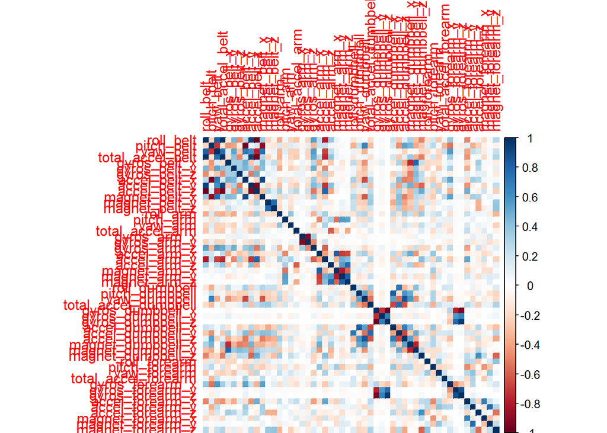

```r
library(corrplot)
corrPlot <- cor(training[,-length(names(training))])
corrplot(corrPlot, method="color")
```

```r
varImp(model)
```

```
## rf variable importance
##
##   only 20 most important variables shown (out of 52)
##
##                      Overall
## roll_belt            100.000
## pitch_forearm         57.677
## yaw_belt              55.385
## pitch_belt            45.852
## roll_forearm          43.780
## magnet_dumbbell_y     43.447
## magnet_dumbbell_z     42.098
## accel_dumbbell_y      22.511
## accel_forearm_x       18.982
## magnet_dumbbell_x     18.718
## roll_dumbbell         18.020
## magnet_belt_z         15.039
## accel_dumbbell_z      14.806
## magnet_forearm_z      14.396
## magnet_belt_y         12.516
## accel_belt_z          11.979
## total_accel_dumbbell  11.638
## yaw_arm               10.973
## gyros_belt_z          10.566
## magnet_belt_x          9.521
```